# Econometria Baysiana - Take Home Exam

Bruno Barbosa

13/02/2020

## Question

Consider the regression model $y_i = x_i'\beta + \epsilon_i0$ $\epsilon_i | \lambda_i ,\sigma^2 \sim N(0, \lambda_i\sigma^2)$ where $x_i = (1, x_{i1}, \dots, x_{iq})'$ is a p-dimensional vector of regressors (constant plus q attributes or characteristics) and the following hierarchical prior for the scale-mixing variables $\lambda_i$:
$$\begin{equation}
\lambda_1, \dots, \lambda_n \sim \text{iid Exponential(1/2)}
\end{equation}$$

### PART A)

We will show that
$$\begin{equation}
p\left(\epsilon_{i} | \sigma^{2}\right)=\int_{0}^{\infty} p\left(\epsilon_{i} | \lambda_{i}, \sigma^{2}\right) p\left(\lambda_{i}\right) d \lambda_{i}=\frac{1}{2 \sigma} \exp \left\{-\frac{\left|\epsilon_{i}\right|}{\sigma}\right\}
\end{equation}$$

First consider $p\left(\epsilon_{i} | \sigma^{2}\right)$, then we must have that:
$$\begin{align}
p\left(\epsilon_{i} | \sigma^{2}\right) &=\int_{0}^{\infty} p\left(\epsilon_{i} | \lambda_{i}, \sigma^{2}\right) p\left(\lambda_{i}\right) d \lambda_{i} \\
&=\int_{0}^{\infty}\left(2 \pi \lambda_{i} \sigma^{2}\right)^{-1 / 2} \exp \left[-\epsilon_{i}^{2} /\left(2 \lambda_{i} \sigma^{2}\right)\right](1 / 2) \exp \left(-\lambda_{i} / 2\right) d \lambda_{i} \\
&=(1 / 2)\left(2 \pi \sigma^{2}\right)^{-1 / 2} \int_{0}^{\infty} \lambda_{i}^{-1 / 2} \exp \left[-(1 / 2)\left(\lambda_{i}+\left[\epsilon_{i} / \sigma\right]^{2} \lambda_{i}^{-1}\right)\right] d \lambda_{i}
\end{align}$$

Now, make a change of variable and let $\psi_i = \lambda_i^{1/2}$. We can then express this integral as
$$\begin{equation}
p\left(\epsilon_{i} | \sigma^{2}\right)=\left(2 \pi \sigma^{2}\right)^{-1 / 2} \int_{0}^{\infty} \exp \left(-[1 / 2]\left(\psi_{i}^{2}+\left[\epsilon_{i} / \sigma\right]^{2} \psi_{i}^{-2}\right)\right) d \psi_{i}
\end{equation}$$

The integral in above can be evaluated analytically. Using the following result from Andrews and Mallows (1974)
$$\int_{0}^{\infty} \exp \left\{-0.5\left(a^{2} u^{2}+b^{2} u^{-2}\right)\right\} d u=\left(\frac{\pi}{2 a^{2}}\right)^{1/2} \exp \{-|a b|\}$$
Then $a=1$, $b=\epsilon_i/\sigma$, and $u = \psi_i$

$$p\left(\epsilon_{i} | \sigma^{2}\right)=\left(2 \pi \sigma^{2}\right)^{-1 / 2} \left(\frac{\pi}{2}\right)^{1/2} \exp\{-|\epsilon_i/\sigma|\} =\frac{1}{2\sigma} \exp\left\{-\frac{|\epsilon_i|}{\sigma}\right\}$$

### PART B)

Let $y = (y_1, \dots, y_n)'$ and $X = (x_1, \dots, x_n)'$. Where we have the the following independent priors for $\beta \sim N(\beta_0, V_0)$ and $\sigma^2 \sim IG\left(\frac{\nu_0}{2}, \frac{\nu_0\sigma_0^2}{2}\right)$. Also let $\mathcal{D} = \{y;X\}$, and $\Lambda$ be denoted as follows
$$\Lambda = \begin{bmatrix}\lambda_1 & 0 & \dots & 0 \\ 0 & \lambda_2 & \dots & 0 \\ 0 & \vdots & \ddots & 0 \\ 0 & 0 & 0 & \lambda_n \end{bmatrix}$$
To implement the Gibbs sampler we need to obtain the complete posterior conditionals for the parameters $\beta$, $\sigma^2$, and $\{\lambda_i\}_{i=1}^{n}$ and cycle through the posteriors conditional distributions. The joint posterior distribution is given as
$$\begin{equation}
p\left(\beta,\left\{\lambda_{i}\right\}, \sigma^{2} | y\right) \propto\left[\prod_{i=1}^{n} \phi\left(y_{i} ; x_{i} \beta, \lambda_{i} \sigma^{2}\right) p\left(\lambda_{i}\right)\right] p(\beta) p\left(\sigma^{2}\right)
\end{equation}$$

We know that traditional GLS have that $\beta = (X^T\Lambda^{-1}X)^{-1}X^T\Lambda^{-1}y$. If $\beta \sim N(\beta_0, V_0)$, and $\sigma^2 \sim IG\left(\frac{\nu_0}{2}, \frac{\nu_0 \sigma_0^2}{2}\right)$ then from the joint posterior, the following complete conditional posterior distributions are obtained:

#### The $\beta$ conditional distribution ($\beta | \{\lambda_i\}, \sigma^2, \mathcal{D}$)

$$\begin{align}
p\left(y | X, \beta, \sigma^{2}, \{\lambda_i\}\right)
&\propto \exp \left\{-\frac{1}{2 \sigma^{2}} \sum_{i=1}^{n} \hat\epsilon_i^2 \right\} \\
&\propto \exp \left\{-\frac{1}{2 \sigma^{2}}\left[y^{T} y-2 \beta^{T} X^{T}\Lambda^{-1} y+\beta^{T} X^{T}\Lambda^{-1} X \beta\right]\right\} \\
p\left(\beta | \{\lambda_i\}, \sigma^2, \mathcal{D}\right) &\propto p\left(y | X, \beta, \sigma^{2}\right) \times p(\beta) \\
&\propto \exp \left\{-\frac{1}{2\sigma^2}\left(-2 \beta^{T} X^{T}\Lambda^{-1} y +\beta^{T} X^{T}\Lambda^{-1} X \beta \right)-\frac{1}{2}\left(-2 \beta^{T} V_{0}^{-1} \beta_{0}+\beta^{T} V_{0}^{-1} \beta\right)\right\} \\
&\propto
\exp \left\{-\frac{1}{2}\left(-2 \beta^{T} (X^{T}\Lambda^{-1} y/\sigma^2 +V_{0}^{-1} \beta_{0})+ \beta^{T} (X^{T}\Lambda^{-1} X/\sigma^2 +V_{0}^{-1} ) \beta \right)
\right\}
\end{align}$$
we recognize this as being proportional to a multivariate normal density, with
$$\begin{align}
\beta | \{\lambda_i\}, \sigma^2, \mathcal{D} \sim N(\beta_1, V_1) \\
\beta_{1}=V_{1}\left(X^{\prime} \Lambda^{-1} y/\sigma^2+V_{0}^{-1} \beta_{0}\right) \qquad V_{1}=\left(X^{\prime} \Lambda^{-1} X / \sigma^{2}+V_{0}^{-1}\right)^{-1}
\end{align}$$

#### The $\sigma^2$ conditional distribution ($\sigma^2| \Lambda, \mathcal{D}, \beta$)

As in most normal sampling problems, the semiconjugate prior distribution for $\sigma^2$ is an inverse-gamma distribution. Letting $\gamma = 1/\sigma^2$ be the measurement precision, this implies that $\gamma \sim G\left(\frac{\nu_0}{2}, \frac{\nu_0\sigma_0^2}{2}\right)$ then
$$\begin{align}
p(\gamma | \mathcal{D}, \beta) & \propto p(\gamma) p(y | X, \beta, \gamma) \\
& \propto\left[\gamma^{\nu_{0} / 2-1} \exp \left\{-\gamma \times \frac{ \nu_{0} \sigma_{0}^{2}}{2}\right\}\right] \times\left[\gamma^{\frac{n}{2}} \exp \left\{- \frac{\gamma }{2} \sum_{i=1}^{n} \hat\epsilon_i^2\right\}\right] \\
& \propto\gamma^{\left(\nu_{0}+n\right) / 2-1} \exp \left\{-\gamma\left[\nu_{0} \sigma_{0}^{2}+\sum_{i=1}^{n} \hat\epsilon_i^2\right] / 2\right\}
\end{align}$$
which we recognize as a gamma density, so that
$$\sigma^2| \Lambda, \mathcal{D}, \beta \sim IG\left(\frac{\nu_0 + n}{2}, \frac{\nu_0 \sigma_0^2 + \sum_{i=1}^{n} \hat\epsilon_i^2}{2}\right)$$
Recall that $\sum_{i=1}^{n} \hat\epsilon_i^2 = (y - X\beta)^T\Lambda^{-1}(y-x\beta)$
$$\begin{align}
\sigma^2| \Lambda, \mathcal{D}, \beta &\sim IG\left(\frac{\nu_0 + n}{2}, \frac{\nu_0 \sigma_0^2 + (y - X\beta)^T\Lambda^{-1}(y-x\beta)}{2}\right) \\
\sigma^2| \Lambda, \mathcal{D}, \beta &\sim IG\left(\frac{\nu_1}{2}, \frac{\nu_1 \sigma_1^2}{2}\right) \\
&\nu_1 = \nu_0 + n \qquad \nu_1\sigma_1^2 = \nu_0\sigma_0^2 + (y - X\beta)^T\Lambda^{-1}(y-x\beta)
\end{align}$$

#### The $\lambda_{i}$ conditional distribution ($\lambda_{i} | \beta, \sigma^{2}, \mathcal{D}$)

Lastly we have that
$$\begin{align}
p\left(\lambda_{i} | \beta, \sigma^{2}, y_{i}, x_{i}\right) &\propto p\left( y_{i}| \lambda_{i}, \beta, \sigma^{2}, x_{i}\right) p(\lambda_{i}) \\
p\left(\lambda_{i} | \beta, \sigma^{2}, y_{i}, x_{i}\right) &\propto \frac{1}{\sqrt{2\pi \sigma^2 \lambda} }\exp \left\{-\frac{1}{2}\left(\left(y_{i}-x_{i}^{T} \beta\right)^{2} \sigma^{-2}\lambda_{i}^{-1}\right)\right\} \exp \left\{-0.5 \lambda_{i}\right\} \\
p\left(\lambda_{i} | \beta, \sigma^{2}, y_{i}, x_{i}\right) &\propto \lambda^{-1 / 2} \exp \left\{-0.5 \lambda_{i}\right\}
\exp \left\{-0.5\left(\left(\frac{y_{i}-x_{i}^{\prime} \beta}{\sigma}\right)^{2} \lambda_{i}^{-1}\right)\right\} \\
p\left(\lambda_{i} | \beta, \sigma^{2}, y_{i}, x_{i}\right) &\propto \lambda^{-1 / 2} \exp \left\{-0.5\left(\lambda_{i}+\left(\frac{y_{i}-x_{i}^{\prime} \beta}{\sigma}\right)^{2} \lambda_{i}^{-1}\right)\right\}
\end{align}$$

We claim that this distribution is of the generalized inverse Gaussian (GIG) form. Following Shuster (1968), Michael, et. al. (1976), and Carlin and Polson (1991), we outline a strategy for obtaining a draw from this GIG density.

We say that $x$ follows an inverse Gaussian distribution ($x \sim invGauss(\psi, \mu)$) if
$$\begin{equation}
p(x | \psi, \mu) \propto x^{-3 / 2} \exp \left(-\frac{\psi(x-\mu)^{2}}{2 x \mu^{2}}\right), \quad x>0
\end{equation}$$

Now, let $z = x^{−1}$. It follows by a change of variables that
$$\begin{align}
p(z | \psi, \mu) &\propto z^{-2} z^{3 / 2} \exp \left(-\frac{\psi\left(z^{-1}-\mu\right)^{2}}{2 z^{-1} \mu^{2}}\right) \\
& \propto z^{-1 / 2} \exp \left(-\frac{\psi}{2}\left[z+\mu^{-2} z^{-1}\right]\right)
\end{align}$$

Then notice that the posterior conditional for $\lambda_i$, follows that the reciprocal of an $invGauss(1, |\sigma/(y_i - x_i\beta)|)$. **This means that a draw of $\lambda_i$ can be done by inverting a draw from the inverse Gaussian distribution.** Then, the only step is to draw from the inverse Gaussian distribution.

Shuster (1968) notes that if $x$ has the inverse Gaussian density, then $\psi(x − \mu)^2/x\mu^2 \sim \chi^2(1)$, a chi-square distribution with one degree of freedom. Let $\nu_2 = \psi(x − \mu)^2/x\mu^2$, them the roots of $nu_2$, denoted here as $x_1$ and $x_2$ are obtained as
$$\begin{align}
&x_{1}=\mu+\frac{\mu^{2} \nu_{2}}{2 \psi}-\frac{\mu}{2 \psi} \sqrt{4 \mu \psi \nu_{2}+\mu^{2} \nu_{2}^{2}}\\
&x_{2}=\mu^{2} / x_{1}
\end{align}$$

Michael et al. (1976) use this idea to show that one can obtain a draw from the inverse Gaussian $(\psi, \mu)$ density by first drawing $\nu_2 \sim \chi^2(1)$, calculating the roots $x_1$ and $x_2$ from the preceding equations, and then setting $x$ equal to $x_1$ with probability $\mu/(\mu + x_1)$ and equal to x2 with probability $x_1/(\mu + x_1)$.

### PART C)

We now simulate $n = 200$ observations from the above linear regression with double exponential errors model, where $\beta = (0, 1, 2, 3)'$, $\sigma^2 = 1$ and $x_{ij} \sim N(0, 1)$. Afther the simulation we implement the above MCMC scheme and produce posterior summaries of the main parameters. We also try to answer if the simple MH algorithm to sample $\lambda_i$ be reasonable for your simulated data or the full-fledge Gibbs sampler performs better.

We first load libraries and clear any variables to start with a clear enviroment.

```r
# Libraries
library(statmod) # Used for Inverse Gausian
library(nimble)  # Used for double exponential
library(tictoc)  # Used for Time Evaluation

# Clear Vars
rm(list = ls())
```

For the Full metropolis hasting we will need to determine the proposal functions and likelihood functions.

```r
func_q = function(lambda_i, y_i, x_i, beta, sigma)
{
  ret = -0.5*log(lambda_i) -0.5*(lambda_i+( (y_i - x_i %*% beta)/sigma  )^2 * 1/lambda_i)
  return(ret)
}

func_F = function(lambda_i, y_i, x_i, beta, sig2)
{
  erro = y_i - x_i%*%beta
  ret = dnorm(erro, mean = 0, sd = (sig2*lambda_i)^0.5, log = TRUE) - lambda_i/2
  return(ret)
}
```

We now start with the initial setup. We fix a seed por replication porposes, and set the initial values of $X = \{x_{i1}, x_{i2}, x_{i3}, x_{i4} \}_{i=1}^{n}$

```r
# Replication Seed
set.seed(12345)

# Sample size
n = 200

# regressors
nregress = 4
beta_true = as.matrix(0:(nregress-1), nregress,1)

# Regressors Matrix
X = matrix(rnorm(nregress*n,0,1), n, nregress)

# Declare of sigma
sigma_true = 1
```

We then we proced seting up the simulation. We use a draw form the double exponential for the erros, however a draw for lambda and then the construction of the errors could also be used.

```r
# We opt to use the Double exponential extrection
USE_DOUBLE_EXP = TRUE

# Simulacao
if(USE_DOUBLE_EXP){
  error_true = nimble::rdexp(n, location = 0, scale = sigma_true)
} else
{
  lambda_true = rexp(n,1/2)
  error_true  = rnorm(n, 0, sqrt(sigma_true*lambda_true))
}

# Simulation
Y <- X%*%beta_true + error_true
```

Ouw first step is to look at the classical OLS estimator.

```r
# Ols model
ols = lm(Y ~ X -1);
sigma2.ols = summary(ols)$sigma^2
beta.ols = matrix(ols$coefficients, nregress, 1)
summary(ols)
```

```
##
## Call:
## lm(formula = Y ~ X - 1)
##
## Residuals:
##     Min      1Q  Median      3Q     Max
## -3.6968 -0.7314  0.1168  0.7823  4.7151
##
## Coefficients:
##    Estimate Std. Error t value Pr(>|t|)
## X1 -0.03397    0.08843  -0.384    0.701
## X2  0.86260    0.09895   8.718  1.2e-15 ***
## X3  1.96746    0.09744  20.191  < 2e-16 ***
## X4  2.93288    0.09408  31.175  < 2e-16 ***
## ---
## Signif. codes:  0 '***' 0.001 '**' 0.01 '*' 0.05 '.' 0.1 ' ' 1
##
## Residual standard error: 1.338 on 196 degrees of freedom
## Multiple R-squared:  0.8689, Adjusted R-squared:  0.8663
## F-statistic: 324.9 on 4 and 196 DF,  p-value: < 2.2e-16
```

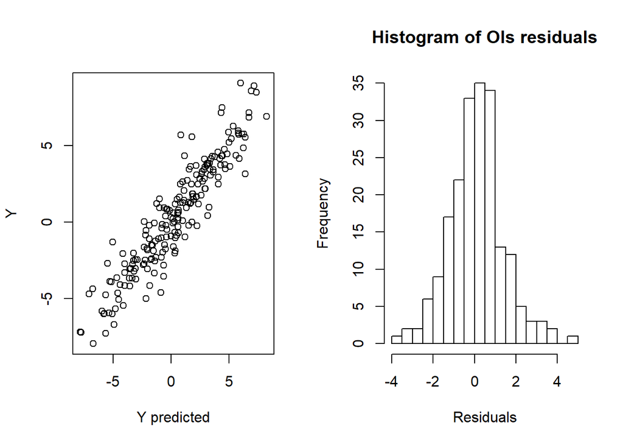

```r
# histogram
par(mfrow=c(1,2))
plot(X%*%beta_true, Y, xlab = "Y predicted", ylab = "Y")
hist(ols$residuals, breaks=15, main="Histogram of Ols residuals", xlab = "Residuals", ylab = "Frequency")
```

```r
# MCMC set-up
M0    = 1000  # Final
M     = 10000 # Burn up
niter = M0+M


# TABLE DRAWS
ncol.draws = 1 + nregress
draws.mc = matrix(0, nrow = niter, ncol = ncol.draws)
colnames(draws.mc) = c("sigma", paste("beta", 1:nregress))

draws.gibbs = matrix(0, nrow = niter, ncol = ncol.draws)
colnames(draws.gibbs) = c("sigma", paste("beta", 1:nregress))
```

For the Priors we will set the following. we will assume that $\beta_0 = 0$, this impplies that we do not expect $Y$ to be correlated with $X$, however we are insecure about this fact and assume a standard deviation of 5 for each beta ($V_0 = diag(25)_{n=4}$). For $\sigma^2$ we will set the priors $\sigma_0 = 1$ and $\nu_0 = 2.5$. We also set the initial values for our interations.

```r
# priors of beta
beta_0 = matrix(0, nregress, 1)
V_0 = diag(25, nregress)

# priors of sigma
sigma2_0 = 1
nu_0 = 2.5

# initial Values
sigma2 = sigma2.ols
beta = beta.ols
lambda = rep(1,n)
```

Then we proceed with the MCMC, one could make the draw from the inverse Gaussian using the *statmod* r package or the procedure done by michael et. al.

```r
# We opt to use Michael method
USE_MICHAEL_METHOD = TRUE

# table to store execution time
dt_time = data.frame(Method = c("MH", "GIBBS"), Time = NA, ess=NA, ess_ps = NA)
for (k in 1:2) {
  if(k==1)
  { MH = TRUE }
  else
  { MH=FALSE }

  tictoc::tic(MH)
  for (i in 1:(niter)){

    # Inicialize Lambda^{-1}  matrix
    Lambda_1 = solve(diag(lambda))

    # full conditional of sigma2
    d0=(nu_0 * sigma2_0)/2
    par1 = (nu_0 + n)/2
    par2 = d0 + ( t(Y-X%*%beta) %*% Lambda_1 %*% (Y-X%*%beta) )/2

    # Conditional distribution of sigma
    sig2 = 1/rgamma(1, par1, par2)

    # full conditional of beta
    XtX = t(X) %*% Lambda_1 %*% X
    XtY = t(X) %*% Lambda_1 %*% Y

    V_1   = solve(XtX/sig2 + solve(V_0))
    beta_1 = V_1 %*% (XtY/sig2 + solve(V_0) %*% beta_0)
    beta =  beta_1 + t(chol(V_1)) %*% rnorm(nregress)

    # Foolowing Koop. (Bayesian Econometrics Methods) pag 260

    # Draw of lambda
    for (j in 1:n){
      y_j = Y[j, 1]
      x_j = X[j, ]

      # draw de nu_0
      nu_michael_0 = rchisq(1,1)

      # mu for row j
      mu_j = abs(sqrt(sig2)/(y_j - x_j %*% beta))

      if(USE_MICHAEL_METHOD){
        #  x1 e x2
        x_1 = mu_j + (mu_j^2 * nu_michael_0)/2 - mu_j/2 * (4 * mu_j * nu_michael_0 + mu_j^2 * nu_michael_0^2)^0.5
        x_2 = mu_j^2 / x_1

        # decide between x_1 and x_2
        p.treshold = mu_j/(mu_j + x_1)
        if (runif(1) < p.treshold)
        {
          x_star = x_1
        }
        else
        {
          x_star = x_2
        }

        # invert x_star
        lambda_j = 1/x_star
      }
      else
      {
        lambda_j = statmod::rinvgauss(1, mu_j, shape = 1)
      }


      # now the Metropolis-Hasting
      if ((lambda_j >0) & (MH)){

        deno = func_F(lambda_j, y_j, x_j, beta, sig2) + func_q(lambda[j], y_j, x_j, beta, sqrt(sig2))
        nume = func_F(lambda[j], y_j, x_j, beta, sig2) + func_q(lambda_j, y_j, x_j, beta, sqrt(sig2))

        log.rho = min(0, nume-deno)
        if (log(runif(1)) < log.rho){
          lambda[j] = lambda_j
        }
      }
      else if (!MH)
      {
        lambda[j] = lambda_j
      }
    }

    # storing draws
    if(MH)
    {draws.mc[i,] = c(sig2, beta)}
    else
    {draws.gibbs[i,] = c(sig2, beta)}

  }

  # Determine Execution Time
  exec_time = tictoc::toc()
  dt_time[k, "Time"] = exec_time$toc - exec_time$tic
  rm(list = c("exec_time"))

  # Determine ESS
  if(MH)
  {
    dt_time[k, "ess"] = round(M/(1+2*sum(acf(draws.mc[,"sigma"],lag.max=1000,plot=FALSE)$acf[2:1001])))
  }
  else
  {
    dt_time[k, "ess"] = round(M/(1+2*sum(acf(draws.gibbs[,"sigma"],lag.max=1000,plot=FALSE)$acf[2:1001])))
  }

}
```

```
## TRUE: 102.48 sec elapsed
## FALSE: 61.17 sec elapsed
```

```r
# Determine the ess per second
dt_time$ess_ps = dt_time$ess / dt_time$Time
```

We them print the distributions

```r
draws2 = data.frame(draws.mc[(M0+1):niter,])
colnames(draws2)
```

```
## [1] "sigma"  "beta.1" "beta.2" "beta.3" "beta.4"
```

```r
summary(draws2$sigma)
```

```
##    Min. 1st Qu.  Median    Mean 3rd Qu.    Max.
##  0.5986  0.9145  1.0045  1.0172  1.1057  1.8359
```

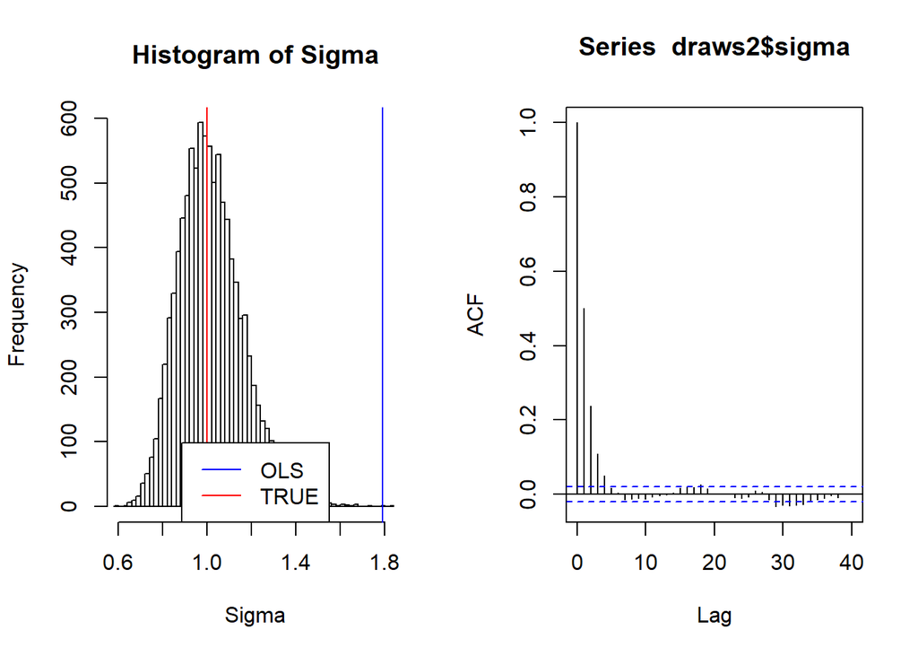

```r
par(mfrow=c(1,2))
hist(draws2$sigma, breaks = 50, main="Histogram of Sigma", xlab = "Sigma", ylab = "Frequency", xlim = range(sigma_true, sigma2.ols, draws2$sigma))
abline(v=sigma_true, col="red")
abline(v=sigma2.ols, col="blue")
legend("bottom", c("OLS", "TRUE"), col = c("blue", "red"), lty=1)
acf(draws2$sigma)
```

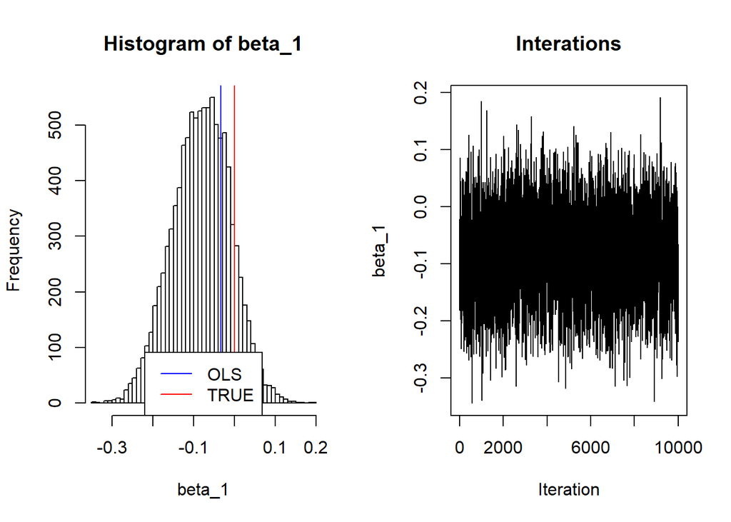

```r
par(mfrow=c(1,2))
hist(draws2$beta.1, breaks = 50, main="Histogram of beta_1", xlab = "beta_1", ylab = "Frequency", xlim = range(beta_true[1], beta.ols[1], draws2$beta.1))
abline(v = beta_true[1], col="red")
abline(v = beta.ols[1], col="blue")
legend("bottom", c("OLS", "TRUE"), col = c("blue", "red"), lty=1)
plot(draws2$beta.1, xlab="Iteration", ylab="beta_1",main="Interations", type = "l")
```

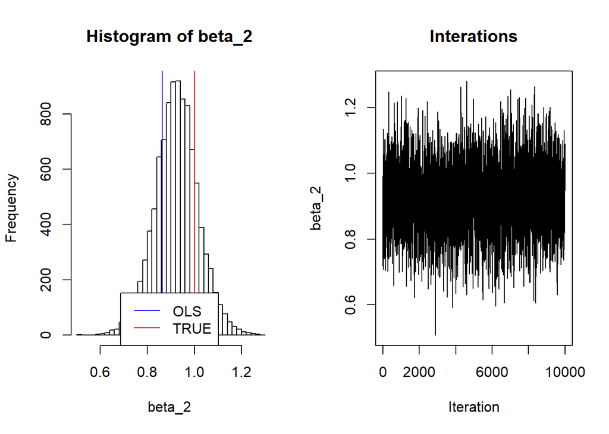

```r
par(mfrow=c(1,2))
hist(draws2$beta.2, breaks = 50, main="Histogram of beta_2", xlab = "beta_2", ylab = "Frequency", xlim = range(beta_true[2], beta.ols[2], draws2$beta.2))
abline(v = beta_true[2], col="red")
abline(v = ols$coefficients[2], col="blue")
legend("bottom", c("OLS", "TRUE"), col = c("blue", "red"), lty=1)
plot(draws2$beta.2, xlab="Iteration", ylab="beta_2",main="Interations", type = "l")
```

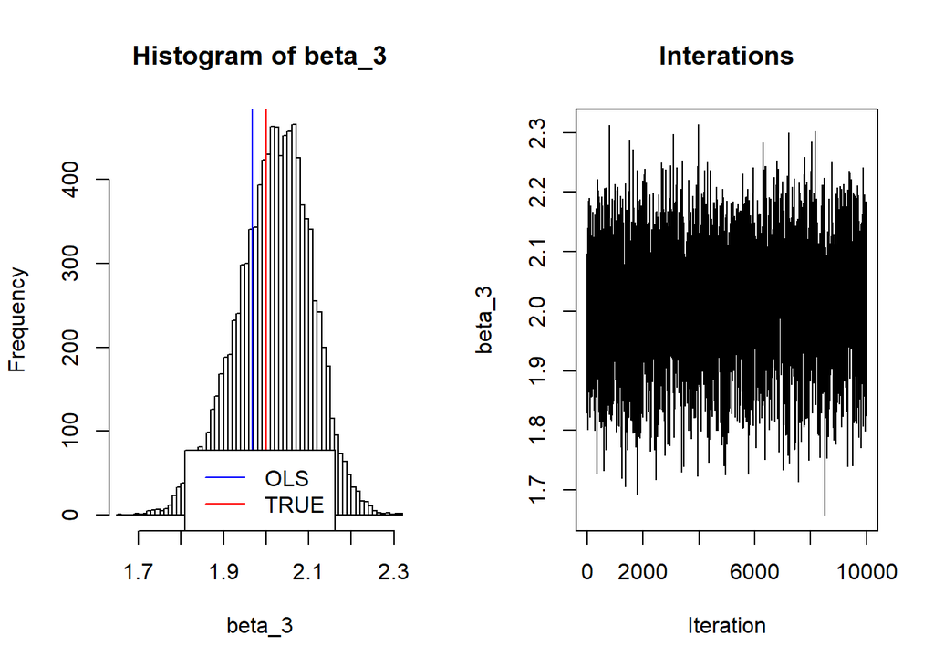

```r
par(mfrow=c(1,2))
hist(draws2$beta.3, breaks = 50, main="Histogram of beta_3", xlab = "beta_3", ylab = "Frequency", xlim = range(beta_true[3], beta.ols[3], draws2$beta.3))
abline(v = beta_true[3], col="red")
abline(v = ols$coefficients[3], col="blue")
legend("bottom", c("OLS", "TRUE"), col = c("blue", "red"), lty=1)
plot(draws2$beta.3, xlab="Iteration", ylab="beta_3",main="Interations", type = "l")
```

[figure not shown]

```r
par(mfrow=c(1,2))
hist(draws2$beta.4, breaks = 50, main="Histogram of beta_4", xlab = "beta_4", ylab = "Frequency", xlim = range(beta_true[4], beta.ols[4], draws2$beta.4))
abline(v = beta_true[4], col="red")
abline(v = ols$coefficients[4], col="blue")
legend("bottom", c("OLS", "TRUE"), col = c("blue", "red"), lty=1)
plot(draws2$beta.3, xlab="Iteration", ylab="beta_4",main="Interations", type = "l")
```

Lastily we evaluate if MH perform better. We present the following table.

```r
dt_time
```

```
##   Method   Time   ess   ess_ps
## 1     MH 102.48 46475 453.5031
## 2  GIBBS  61.17  7443 121.6773
```